# Observations of Red Wine Quality by Subham Biswas

```r
# Load the Data
setwd('C:/Users/abc/Downloads/Udacity_R')
red_wine <-read.csv('wineQualityReds.csv',header= TRUE)
```

```r
# removing the serial number column
red_wine$X <- NULL
#summarising the data set
summary(red_wine)
```

```
##  fixed.acidity   volatile.acidity  citric.acid    residual.sugar
##  Min.   : 4.60   Min.   :0.1200   Min.   :0.000   Min.   : 0.900
##  1st Qu.: 7.10   1st Qu.:0.3900   1st Qu.:0.090   1st Qu.: 1.900
##  Median : 7.90   Median :0.5200   Median :0.260   Median : 2.200
##  Mean   : 8.32   Mean   :0.5278   Mean   :0.271   Mean   : 2.539
##  3rd Qu.: 9.20   3rd Qu.:0.6400   3rd Qu.:0.420   3rd Qu.: 2.600
##  Max.   :15.90   Max.   :1.5800   Max.   :1.000   Max.   :15.500
##    chlorides       free.sulfur.dioxide total.sulfur.dioxide
##  Min.   :0.01200   Min.   : 1.00       Min.   :  6.00
##  1st Qu.:0.07000   1st Qu.: 7.00       1st Qu.: 22.00
##  Median :0.07900   Median :14.00       Median : 38.00
##  Mean   :0.08747   Mean   :15.87       Mean   : 46.47
##  3rd Qu.:0.09000   3rd Qu.:21.00       3rd Qu.: 62.00
##  Max.   :0.61100   Max.   :72.00       Max.   :289.00
##     density             pH          sulphates         alcohol
##  Min.   :0.9901   Min.   :2.740   Min.   :0.3300   Min.   : 8.40
##  1st Qu.:0.9956   1st Qu.:3.210   1st Qu.:0.5500   1st Qu.: 9.50
##  Median :0.9968   Median :3.310   Median :0.6200   Median :10.20
##  Mean   :0.9967   Mean   :3.311   Mean   :0.6581   Mean   :10.42
##  3rd Qu.:0.9978   3rd Qu.:3.400   3rd Qu.:0.7300   3rd Qu.:11.10
##  Max.   :1.0037   Max.   :4.010   Max.   :2.0000   Max.   :14.90
##     quality
##  Min.   :3.000
##  1st Qu.:5.000
##  Median :6.000
##  Mean   :5.636
##  3rd Qu.:6.000
##  Max.   :8.000
```

```r
# printing structure of the dataset
str(red_wine)
```

```
## 'data.frame':    1599 obs. of  12 variables:
##  $ fixed.acidity       : num  7.4 7.8 7.8 11.2 7.4 7.4 7.9 7.3 7.8 7.5 ...
##  $ volatile.acidity    : num  0.7 0.88 0.76 0.28 0.7 0.66 0.6 0.65 0.58 0.5 ...
##  $ citric.acid         : num  0 0 0.04 0.56 0 0 0.06 0 0.02 0.36 ...
##  $ residual.sugar      : num  1.9 2.6 2.3 1.9 1.9 1.8 1.6 1.2 2 6.1 ...
##  $ chlorides           : num  0.076 0.098 0.092 0.075 0.076 0.075 0.069 0.065 0.073 0.071 ...
##  $ free.sulfur.dioxide : num  11 25 15 17 11 13 15 15 9 17 ...
##  $ total.sulfur.dioxide: num  34 67 54 60 34 40 59 21 18 102 ...
##  $ density             : num  0.998 0.997 0.997 0.998 0.998 ...
##  $ pH                  : num  3.51 3.2 3.26 3.16 3.51 3.51 3.3 3.39 3.36 3.35 ...
##  $ sulphates           : num  0.56 0.68 0.65 0.58 0.56 0.56 0.46 0.47 0.57 0.8 ...
##  $ alcohol             : num  9.4 9.8 9.8 9.8 9.4 9.4 9.4 10 9.5 10.5 ...
##  $ quality             : int  5 5 5 6 5 5 5 7 7 5 ...
```

```r
#printing columns in the data set
colnames(red_wine)
```

```
##  [1] "fixed.acidity"        "volatile.acidity"     "citric.acid"
##  [4] "residual.sugar"       "chlorides"            "free.sulfur.dioxide"
##  [7] "total.sulfur.dioxide" "density"              "pH"
## [10] "sulphates"            "alcohol"              "quality"
```

```r
#describing more
describe(red_wine)
```

```
##                      vars    n  mean    sd median trimmed   mad  min
## fixed.acidity           1 1599  8.32  1.74   7.90    8.15  1.48 4.60
## volatile.acidity        2 1599  0.53  0.18   0.52    0.52  0.18 0.12
## citric.acid             3 1599  0.27  0.19   0.26    0.26  0.25 0.00
## residual.sugar          4 1599  2.54  1.41   2.20    2.26  0.44 0.90
## chlorides               5 1599  0.09  0.05   0.08    0.08  0.01 0.01
## free.sulfur.dioxide     6 1599 15.87 10.46  14.00   14.58 10.38 1.00
## total.sulfur.dioxide    7 1599 46.47 32.90  38.00   41.84 26.69 6.00
## density                 8 1599  1.00  0.00   1.00    1.00  0.00 0.99
## pH                      9 1599  3.31  0.15   3.31    3.31  0.15 2.74
## sulphates              10 1599  0.66  0.17   0.62    0.64  0.12 0.33
## alcohol                11 1599 10.42  1.07  10.20   10.31  1.04 8.40
## quality                12 1599  5.64  0.81   6.00    5.59  1.48 3.00
##                         max  range skew kurtosis   se
## fixed.acidity         15.90  11.30 0.98     1.12 0.04
## volatile.acidity       1.58   1.46 0.67     1.21 0.00
## citric.acid            1.00   1.00 0.32    -0.79 0.00
## residual.sugar        15.50  14.60 4.53    28.49 0.04
## chlorides              0.61   0.60 5.67    41.53 0.00
## free.sulfur.dioxide   72.00  71.00 1.25     2.01 0.26
## total.sulfur.dioxide 289.00 283.00 1.51     3.79 0.82
## density                1.00   0.01 0.07     0.92 0.00
## pH                     4.01   1.27 0.19     0.80 0.00
## sulphates              2.00   1.67 2.42    11.66 0.00
## alcohol               14.90   6.50 0.86     0.19 0.03
## quality                8.00   5.00 0.22     0.29 0.02
```

Findings: 1.There are 1599 observations and 13 variables. 2. X is identification id for each observation. 3. Quality is the most important variable as it determines quality of individual sample or observation. 4.Mean Quality is 5.636 and Median is 6 , range is from 3 to 8.

# Univariate Plots Section

I have plotted the mean for all the variables

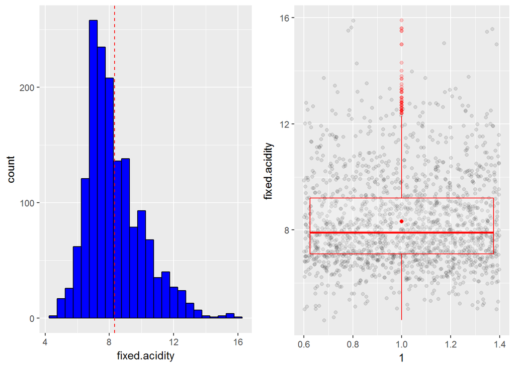

```r
p1 <- ggplot(data = red_wine, aes(x =fixed.acidity))+
  geom_histogram(binwidth = 1/2, color = 'black',fill = 'blue')+
  geom_vline(aes(xintercept=mean(fixed.acidity)),
            color="red", linetype=2)
p2 <- ggplot(red_wine, aes( x = 1, y = fixed.acidity ) ) +
               geom_jitter(alpha = 0.1 ) +
               geom_boxplot(alpha = 0.2, color = 'red' )+
               stat_summary(fun.y = "mean",
               geom = "point",
               color = "red" )
grid.arrange(p1 , p2, ncol = 2)
```

We can see from the plot ,it is almost normal distribution with majority falling between in range 6 to 10 , mean of around 8.5

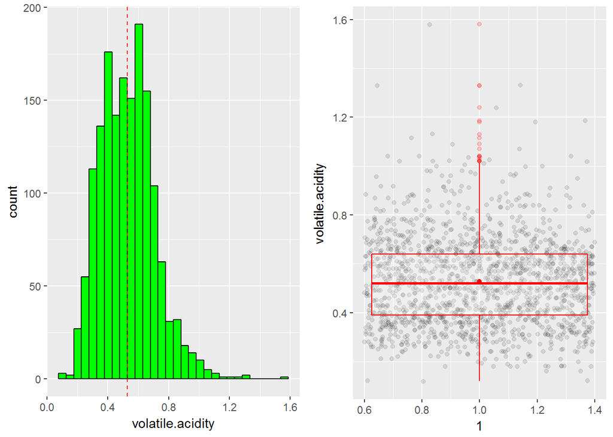

```r
p1 <-  ggplot(data = red_wine, aes(x =volatile.acidity))+
         geom_histogram( color = 'black',fill = 'green')+
         geom_vline(aes(xintercept=mean(volatile.acidity)),
            color="red", linetype=2)
p2 <- ggplot(red_wine, aes( x = 1, y = volatile.acidity ) ) +
               geom_jitter(alpha = 0.1 ) +
               geom_boxplot(alpha = 0.2, color = 'red' )+
               stat_summary(fun.y = "mean",
               geom = "point",
               color = "red" )
grid.arrange(p1 , p2, ncol = 2)
```

We can see from the plot ,it is almost normal distribution with majority falling between in range 0.2 to 0.8 , mean around 0.5

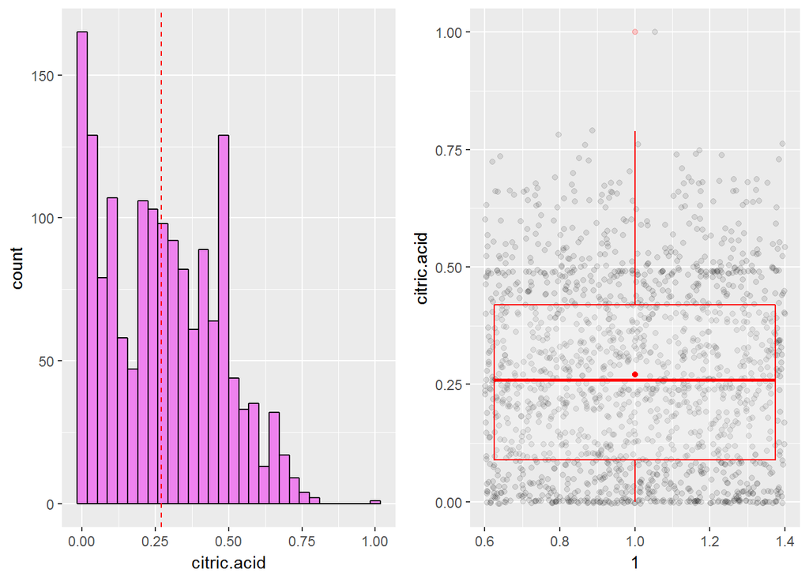

```r
p1 <-   ggplot(data = red_wine, aes(x =citric.acid))+
             geom_histogram( color = 'black',fill = 'violet')+
             geom_vline(aes(xintercept=mean(citric.acid)),
                  color="red", linetype=2)
p2 <- ggplot(red_wine, aes( x = 1, y = citric.acid ) ) +
               geom_jitter(alpha = 0.1 ) +
               geom_boxplot(alpha = 0.2, color = 'red' )+
               stat_summary(fun.y = "mean",
               geom = "point",
               color = "red" )
grid.arrange(p1 , p2, ncol = 2)
```

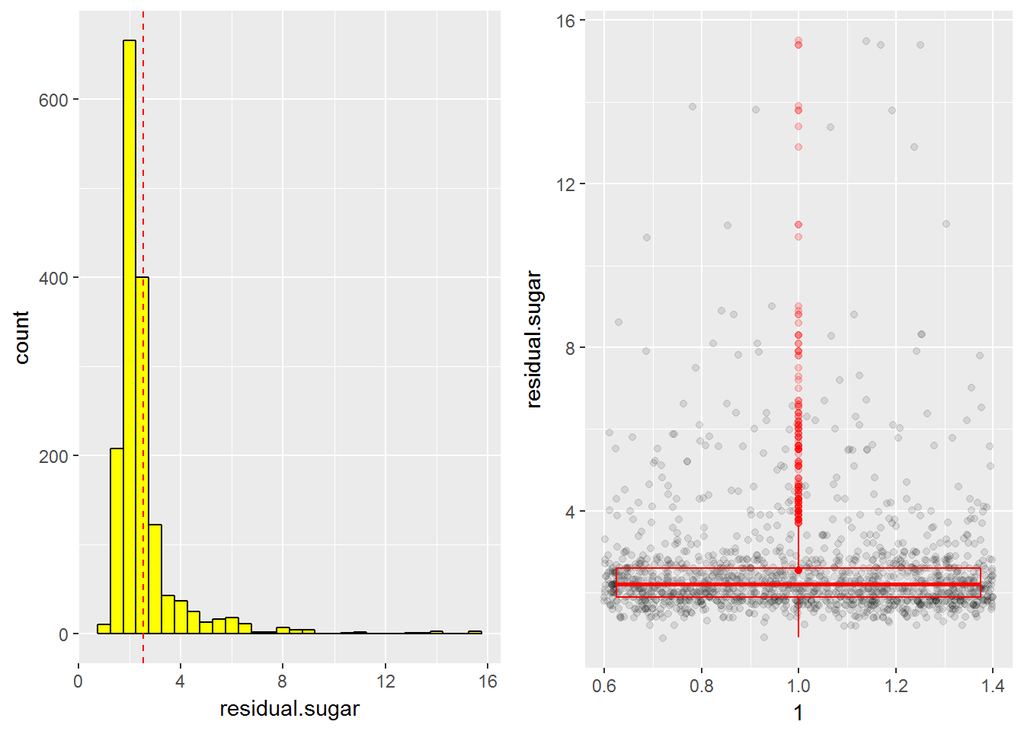

```r
p1 <- ggplot(data = red_wine, aes(x =residual.sugar))+
          geom_histogram(binwidth = 0.5, color = 'black', fill = 'yellow')+
          geom_vline(aes(xintercept=mean(residual.sugar)),
            color="red", linetype=2)
p2 <- ggplot(red_wine, aes( x = 1, y = residual.sugar ) ) +
               geom_jitter(alpha = 0.1 ) +
               geom_boxplot(alpha = 0.2, color = 'red' )+
               stat_summary(fun.y = "mean",
               geom = "point",
               color = "red" )
grid.arrange(p1 , p2, ncol = 2)
```

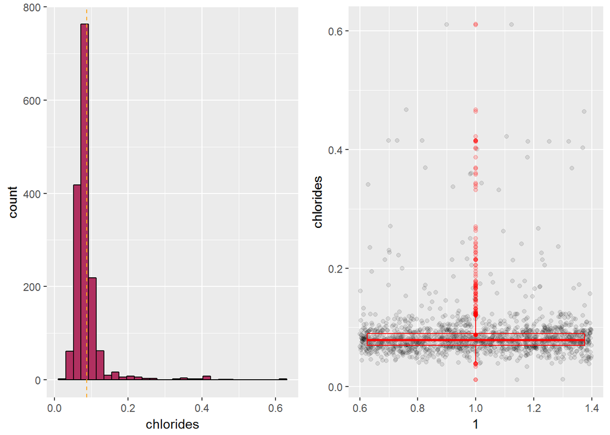

```r
p1 <- ggplot(data = red_wine, aes(x =chlorides))+
           geom_histogram( color = 'black',fill = 'maroon')+
           geom_vline(aes(xintercept=mean(chlorides)),
            color="orange", linetype=2)
p2 <- ggplot(red_wine, aes( x = 1, y = chlorides ) ) +
               geom_jitter(alpha = 0.1 ) +
               geom_boxplot(alpha = 0.2, color = 'red' )+
               stat_summary(fun.y = "mean",
               geom = "point",
               color = "red" )
grid.arrange(p1 , p2, ncol = 2)
```

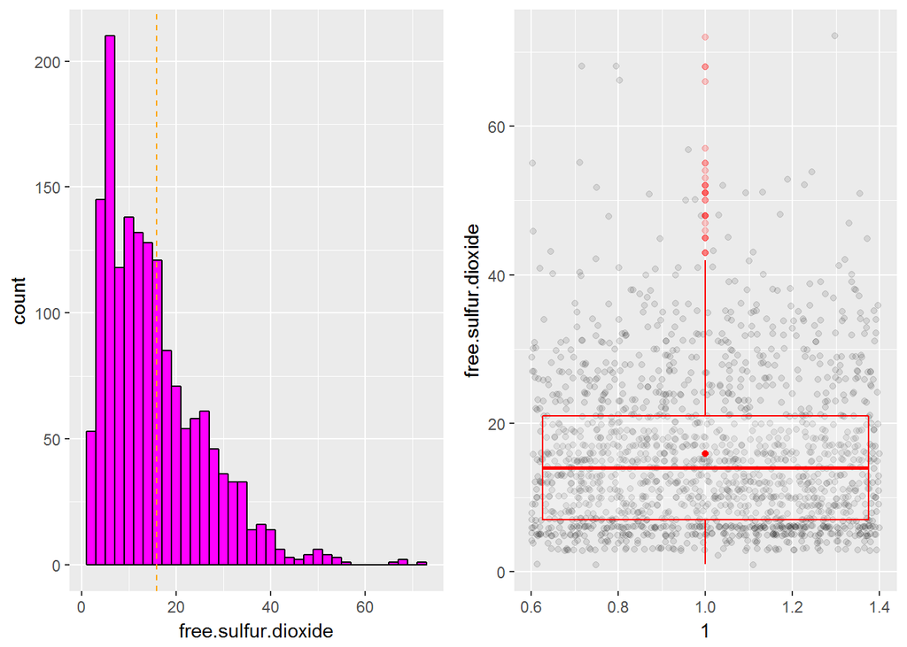

```r
p1 <- ggplot(data = red_wine, aes(x =free.sulfur.dioxide))+
         geom_histogram(binwidth = 2, color = 'black',fill='magenta')+
        geom_vline(aes(xintercept=mean(free.sulfur.dioxide)),
            color="orange", linetype=2)
p2 <- ggplot(red_wine, aes( x = 1, y = free.sulfur.dioxide ) ) +
               geom_jitter(alpha = 0.1 ) +
               geom_boxplot(alpha = 0.2, color = 'red' )+
               stat_summary(fun.y = "mean",
               geom = "point",
               color = "red" )
grid.arrange(p1 , p2, ncol = 2)
```

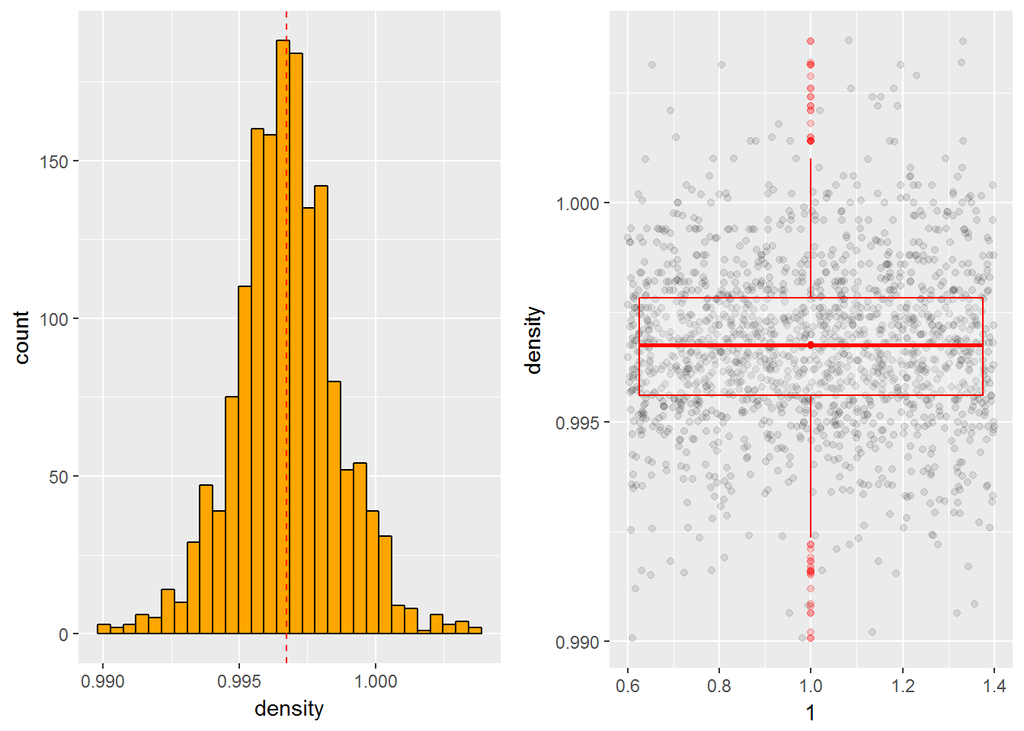

```r
p1<- ggplot(data = red_wine, aes(x =density))+
        geom_histogram(color = 'black',fill ='orange')+
        geom_vline(aes(xintercept=mean(density)),
            color="red", linetype=2)
p2 <- ggplot(red_wine, aes( x = 1, y = density ) ) +
               geom_jitter(alpha = 0.1 ) +
               geom_boxplot(alpha = 0.2, color = 'red' )+
               stat_summary(fun.y = "mean",
               geom = "point",
               color = "red" )
grid.arrange(p1 , p2, ncol = 2)
```

We can see from the plot ,it is almost normal distribution with majority falling between in range 0.995 to 1.0

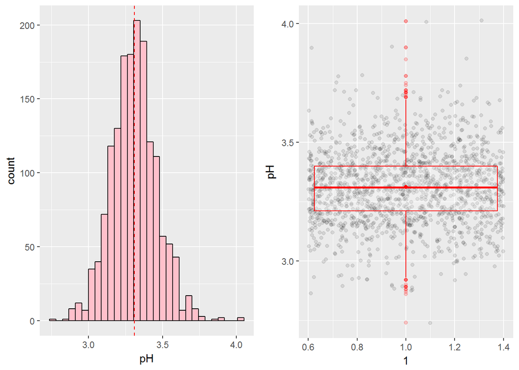

```r
p1 <-  ggplot(data = red_wine, aes(x =pH))+
       geom_histogram( color = 'black',fill = 'pink')+
        geom_vline(aes(xintercept=mean(pH)),
            color="red", linetype=2)
p2 <- ggplot(red_wine, aes( x = 1, y = pH ) ) +
               geom_jitter(alpha = 0.1 ) +
               geom_boxplot(alpha = 0.2, color = 'red' )+
               stat_summary(fun.y = "mean",
               geom = "point",
               color = "red" )
grid.arrange(p1 , p2, ncol = 2)
```

We can see from the plot ,it is almost normal distribution with majority falling between in range 3.0 to 3.7

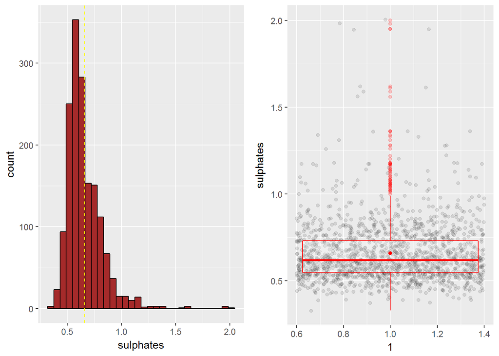

```r
p1 <- ggplot(data = red_wine, aes(x =sulphates))+
               geom_histogram( color = 'black',fill ='brown')+
                geom_vline(aes(xintercept=mean(sulphates)),
                    color="yellow", linetype=2)
p2 <- ggplot(red_wine, aes( x = 1, y = sulphates ) ) +
               geom_jitter(alpha = 0.1 ) +
               geom_boxplot(alpha = 0.2, color = 'red' )+
               stat_summary(fun.y = "mean",
               geom = "point",
               color = "red" )
grid.arrange(p1 , p2, ncol = 2)
```

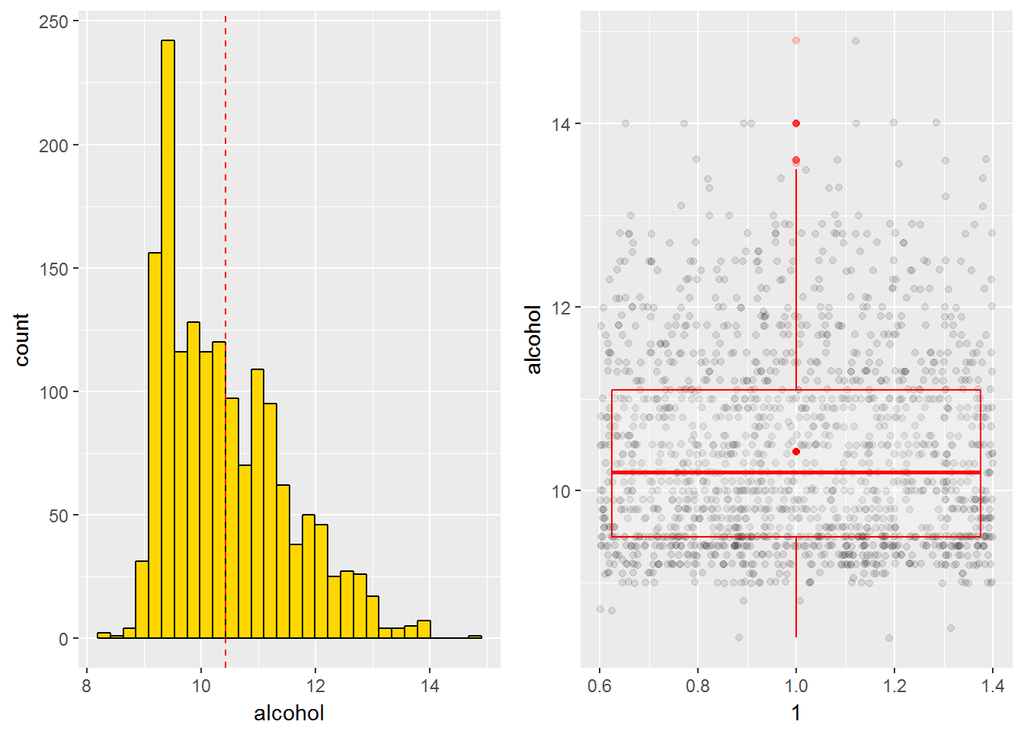

```r
p1 <- ggplot(data = red_wine, aes(x =alcohol))+
            geom_histogram( color = 'black',fill ='gold')+
            geom_vline(aes(xintercept=mean(alcohol)),
                 color="red", linetype=2)
p2 <- ggplot(red_wine, aes( x = 1, y = alcohol ) ) +
               geom_jitter(alpha = 0.1 ) +
               geom_boxplot(alpha = 0.2, color = 'red' )+
               stat_summary(fun.y = "mean",
               geom = "point",
               color = "red" )
grid.arrange(p1 , p2, ncol = 2)
```

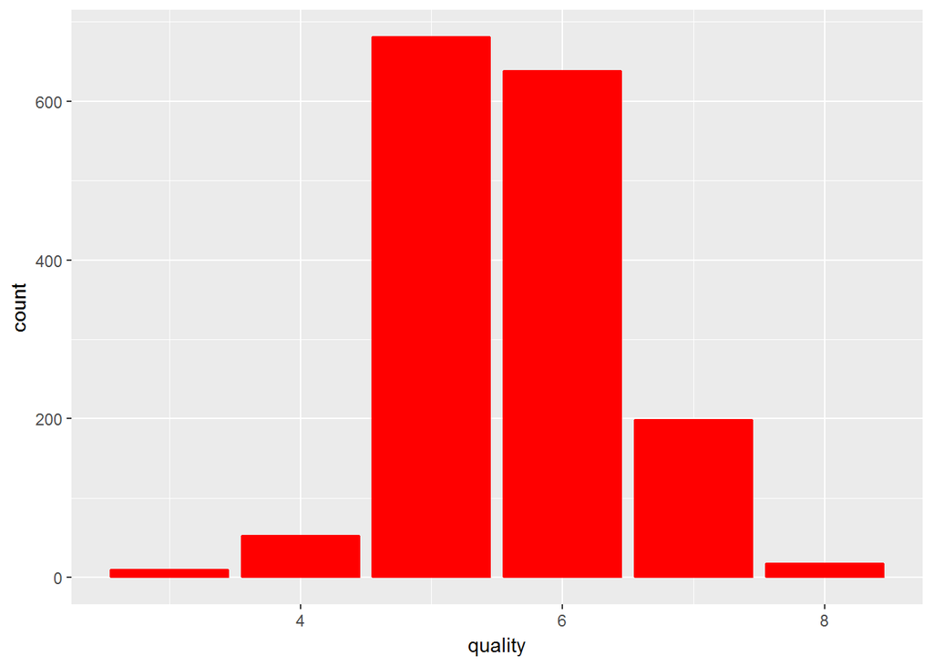

```r
ggplot(data = red_wine, aes(x =quality))+
geom_bar( color = 'red', fill = 'red')
```

We can see from the plot ,the samples are mostly of quality 5 and 6 and least of 3 and 8.That means the bad and good quality wines are very less as compared to average quality wine

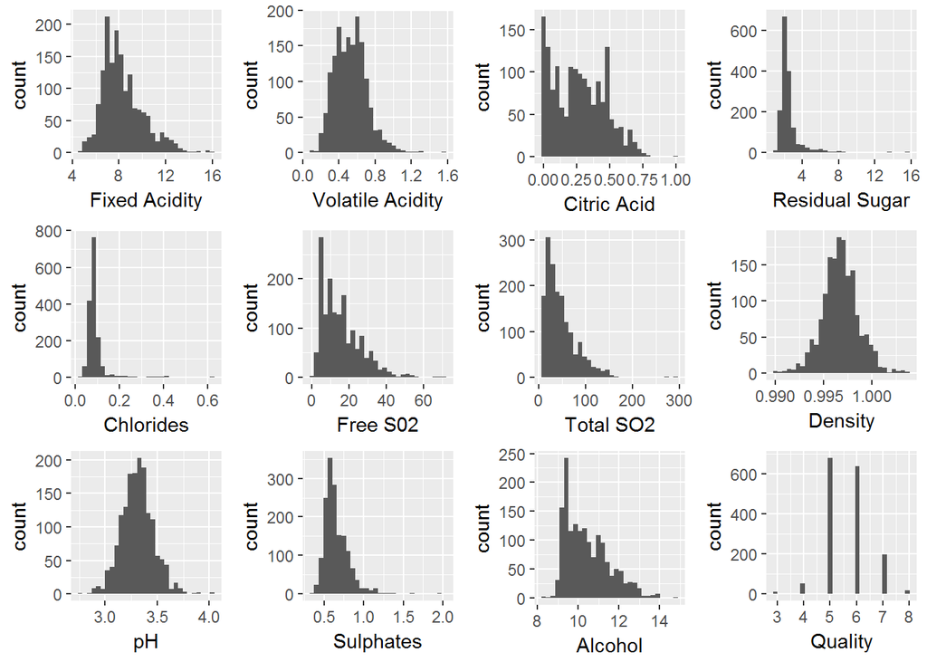

```r
#Plotting all the graphs togetehr in a grid
grid.arrange(qplot(red_wine$fixed.acidity,xlab ='Fixed Acidity'),
             qplot(red_wine$volatile.acidity, xlab = 'Volatile Acidity'),
             qplot(red_wine$citric.acid, xlab = 'Citric Acid'),
             qplot(red_wine$residual.sugar, xlab = 'Residual Sugar'),
             qplot(red_wine$chlorides, xlab = 'Chlorides'),
             qplot(red_wine$free.sulfur.dioxide, xlab = 'Free S02'),
             qplot(red_wine$total.sulfur.dioxide, xlab = 'Total SO2'),
             qplot(red_wine$density, xlab = 'Density'),
             qplot(red_wine$pH, xlab = 'pH'),
             qplot(red_wine$sulphates, xlab = 'Sulphates'),
             qplot(red_wine$alcohol, xlab = 'Alcohol'),
             qplot(red_wine$quality, xlab = 'Quality'),
             ncol = 4)
```

# Univariate Analysis

I first looked at wine quality. Although it has a discrete range of only 3-8, we can roughly see that there is some amount of normal distribution. A large majority of the wines examined received ratings of 5 or 6, and very few received 3, 4, or 8. There’s not much more we can do with this histogram, as both decreasing or increasing bin sizes would distort the data.

Given the ratings and distribution of wine quality, I’ll instantiate another categorical variable, classifying the wines as ‘bad’ (rating 0 to 4), ‘average’ (rating 5 or 6), and ‘good’ (rating 7 to 10).

```
##     bad average    good
##      63    1319     217
```

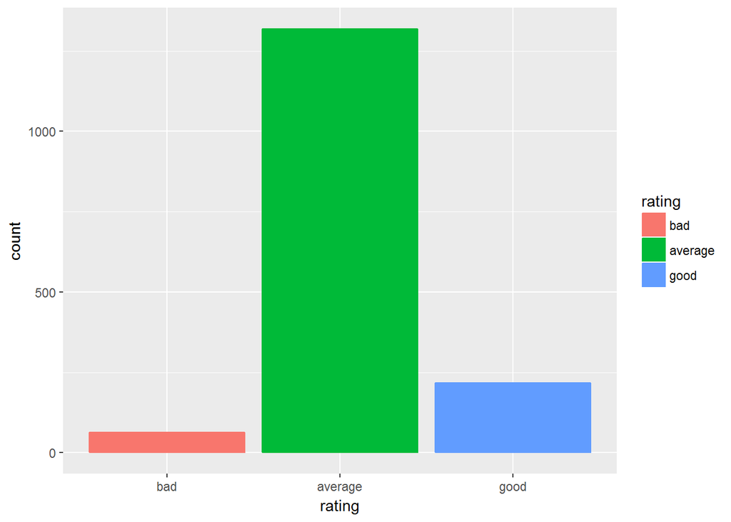

### What is/are the main feature(s) of interest in your dataset?

quality , pH and density are proportional to each other

### What other features in the dataset do you think will help support your investigation into your feature(s) of interest?

SO2, Acidity (both), density are likely to contribute to quality of wine.

### Did you create any new variables from existing variables in the dataset?

I have created rating variable, which is ordered and devide samples in ‘bad’,‘average’,‘good’

### Of the features you investigated, were there any unusual distributions?

According to all the above plots, there are some outliers in some of the features like SO2(free and total), acidity (fixed and volatile).

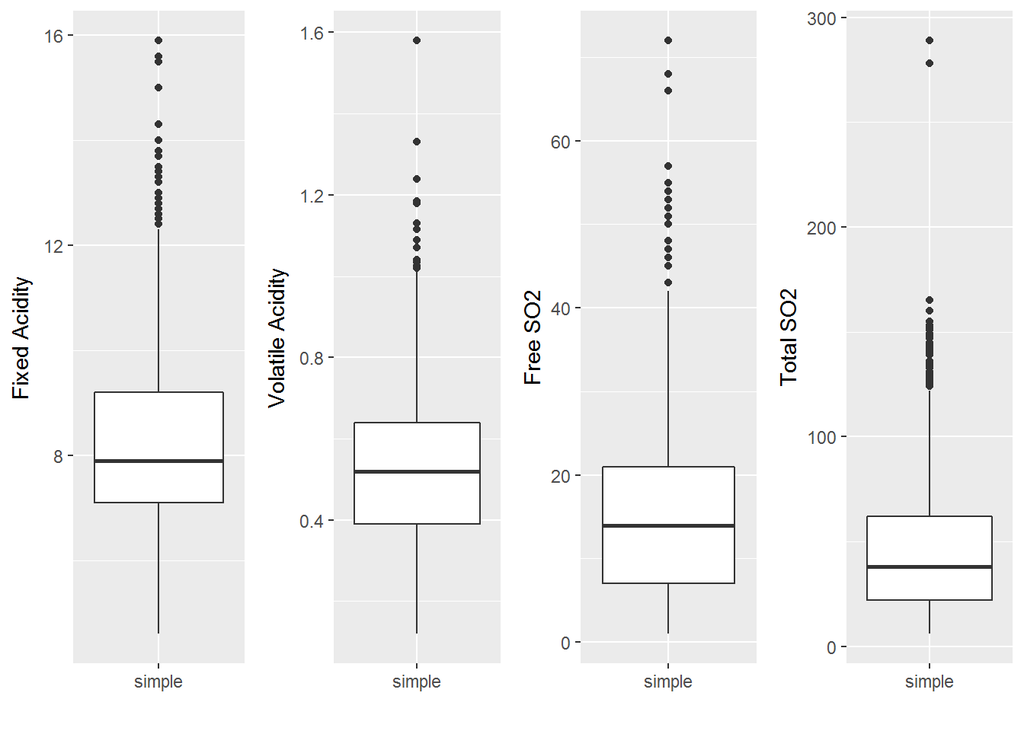

```r
do_boxplot <- function(column, ylab) {
  return(qplot(data = red_wine, x = 'simple',
               y = column, geom = 'boxplot',
               xlab = '',
               ylab = ylab))}
grid.arrange(do_boxplot(red_wine$fixed.acidity,'Fixed Acidity'),
             do_boxplot(red_wine$volatile.acidity,'Volatile Acidity'),
             do_boxplot(red_wine$free.sulfur.dioxide, 'Free SO2'),
             do_boxplot(red_wine$total.sulfur.dioxide,'Total SO2'),
             ncol =4
             )
```

Box plots is very well suited for such plots which have outliers as it can be seen from above figure, we can also see the median for each of the plots.

Also the distribution for Volatile acidity apears to be bimodal normal distribution. But when taking log distribution, the plot becomes normal distributed.

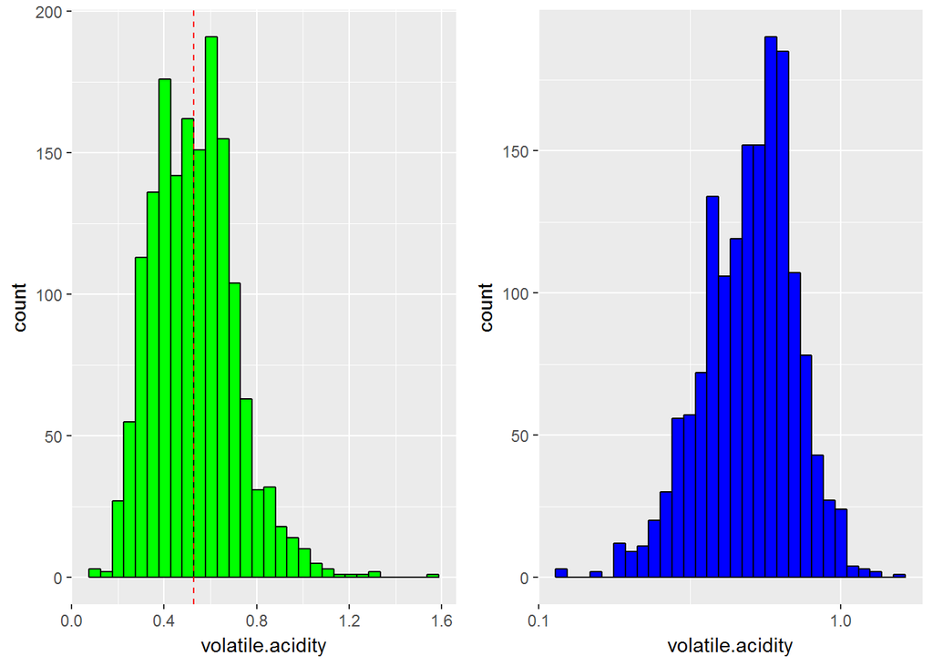

```r
p1 <- ggplot(data = red_wine, aes(x =volatile.acidity))+
  geom_histogram(color = 'black',fill='green') +geom_vline(aes(xintercept=mean(volatile.acidity)),
            color="red", linetype=2)

p2 <- ggplot(data = red_wine, aes(x =volatile.acidity))+
  geom_histogram(color = 'black',fill='blue') +
  scale_x_log10()

grid.arrange(p1 ,p2 ,ncol =2)
```

### Did you perform any operations on the data to tidy, adjust, or change the form ###of the data? If so, why did you do this?

citric.acid have lot of zero values, maybe some records are missing or they are actually zero

```r
summary(red_wine$citric.acid)
```

```
##    Min. 1st Qu.  Median    Mean 3rd Qu.    Max.
##   0.000   0.090   0.260   0.271   0.420   1.000
```

```r
summary(log10(red_wine$citric.acid))
```

```
##    Min. 1st Qu.  Median    Mean 3rd Qu.    Max.
##    -Inf -1.0458 -0.5850    -Inf -0.3768  0.0000
```

We can see that minimum count ,mean for citric.acid is negative infinity that means a lot of observations are zero.

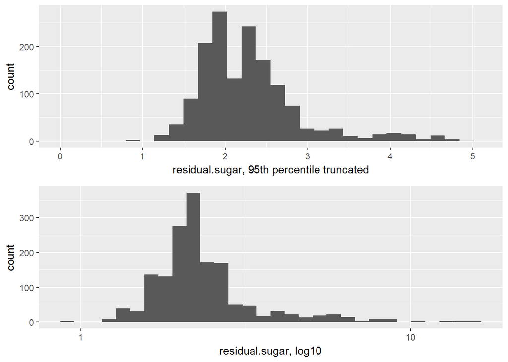

```r
p1 <- ggplot(data = red_wine, aes(x = residual.sugar)) +
  geom_histogram() +
  scale_x_continuous(lim = c(0, quantile(red_wine$residual.sugar, 0.95))) +
  xlab('residual.sugar, 95th percentile truncated')

p2 <- p1 + scale_x_log10() + xlab('residual.sugar, log10')
grid.arrange(p1, p2, ncol=1)
```

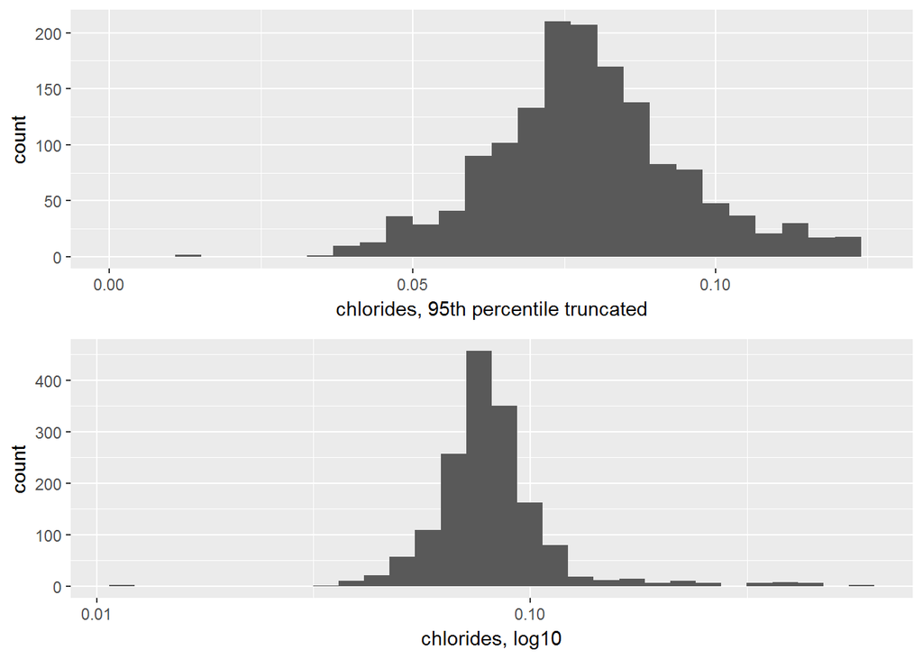

```r
p1 <- ggplot(data = red_wine, aes(x = chlorides)) +
  geom_histogram() +
  scale_x_continuous(lim = c(0, quantile(red_wine$chlorides, 0.95))) +
  xlab('chlorides, 95th percentile truncated')

p2 <- p1 + scale_x_log10() + xlab('chlorides, log10')
grid.arrange(p1, p2, ncol=1)
```

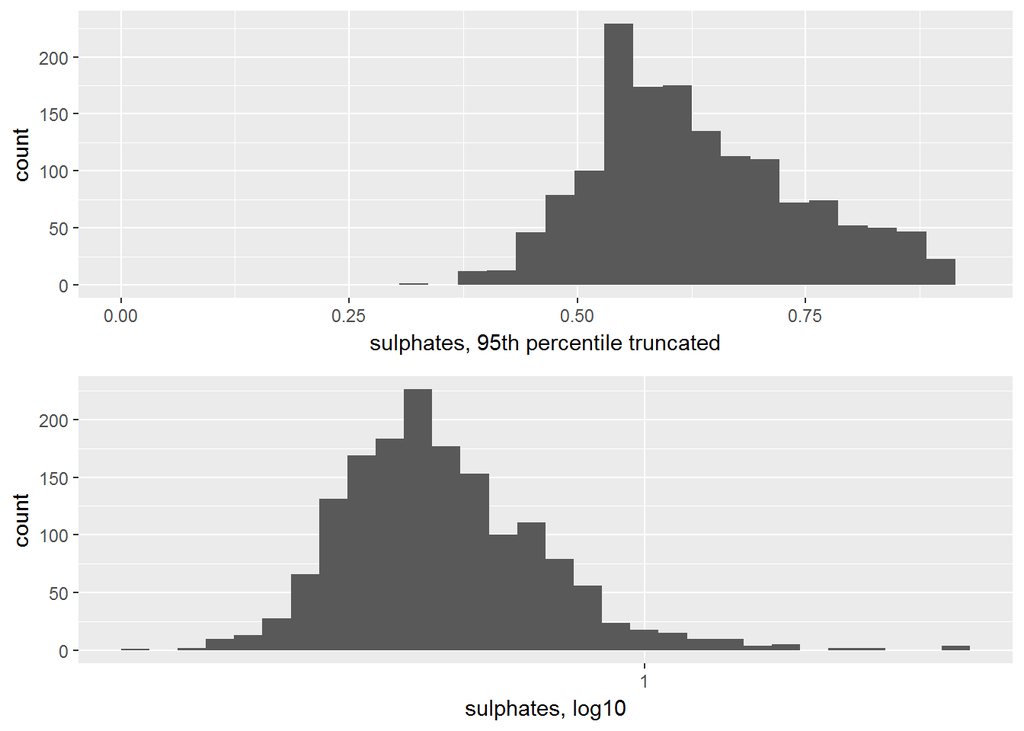

```r
p1 <- ggplot(data = red_wine, aes(x = sulphates)) +
  geom_histogram() +
  scale_x_continuous(lim = c(0, quantile(red_wine$sulphates, 0.95))) +
  xlab('sulphates, 95th percentile truncated')

p2 <- p1 + scale_x_log10() + xlab('sulphates, log10')
grid.arrange(p1, p2, ncol=1)
```

```r
rm(p1, p2)
```

# Bivariate Plots Section

Lets see the correlation behaviour between the features.

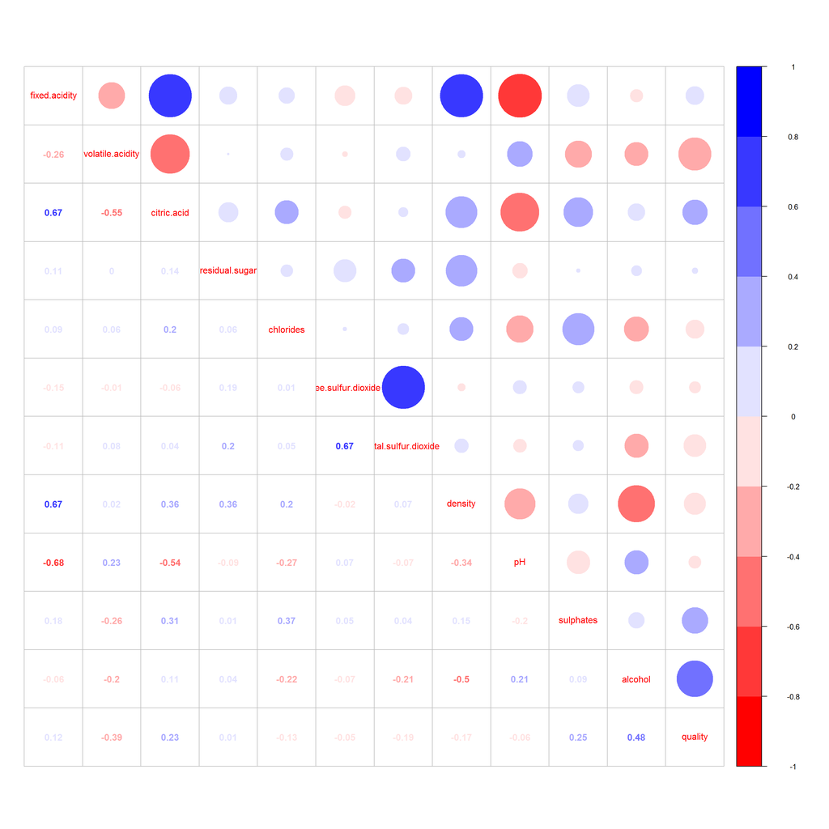

Correlation matrix output shows following behaviour:

## Fixed Acidity

It shows positive correlation with citric acid which is true since citric acid is one of the fixed acid. It also shows positive correlation with density. It also shows significant negative correlation with pH and volatile acidity.

## Volatile Acidity

It is highly negatively correlated with citric acid and quality.

## Free SO2

It shows significant positive correlation with total SO2, and very less correlation with sulphates.

## Quality

Quality and alcohol is positively correlated along with negative correlation with volatile acidity.

First lets plot all the variables that have postive or negative correlation with quality

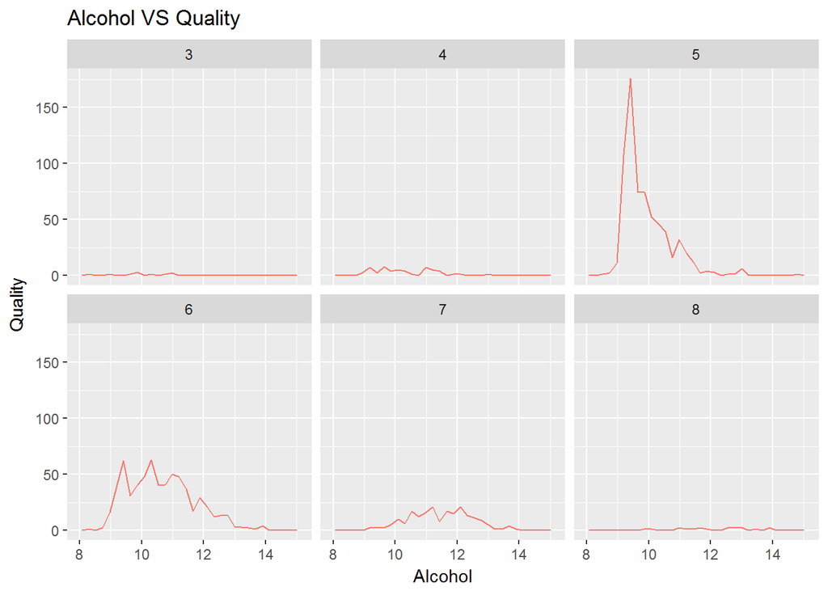

```r
ggplot(red_wine, aes(x =alcohol))+
  geom_freqpoly(aes(color ='red'))+ facet_wrap(~quality)+
  theme(legend.position = "none") +
  ggtitle("Alcohol VS Quality") +
  xlab("Alcohol") +
  ylab("Quality")
```

Only samples with quality 5 and 6 shows high quantity of alcohol ie average Rating samples. But samples with Rating good and bad doesnot show any significant change.

Let us plot and see the mean ,median for all the Quality ratings

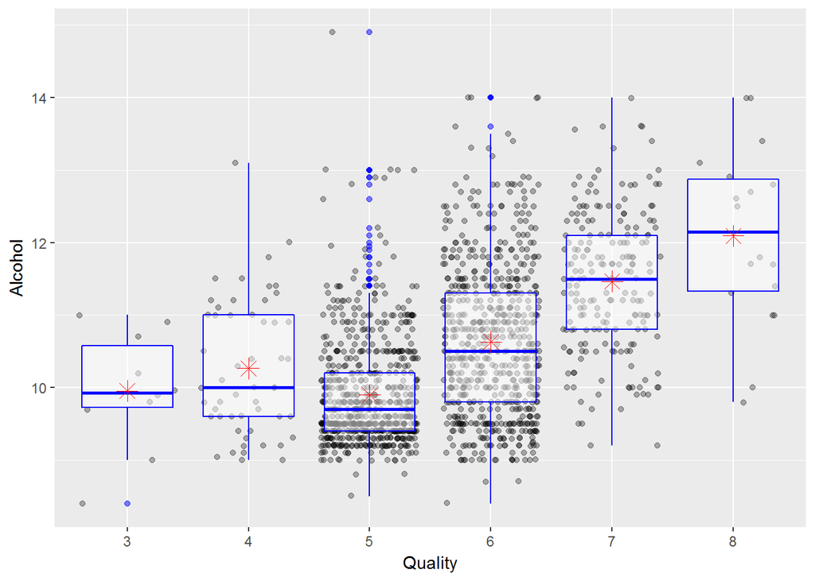

```r
ggplot(aes(factor(quality),
            alcohol),
        data = red_wine) +
  geom_jitter( alpha = .3)  +
  geom_boxplot( alpha = .5,color = 'blue')+
  stat_summary(fun.y = "mean",
               geom = "point",
               color = "red",
               shape = 8,
               size = 4)+
  xlab('Quality')+
  ylab('Alcohol')
```

Higher Quality wine have high mean and median value of Alcohol as compared to Lowest Quality of Red Wine.

Let us plot the Alcohol vs Rating graph

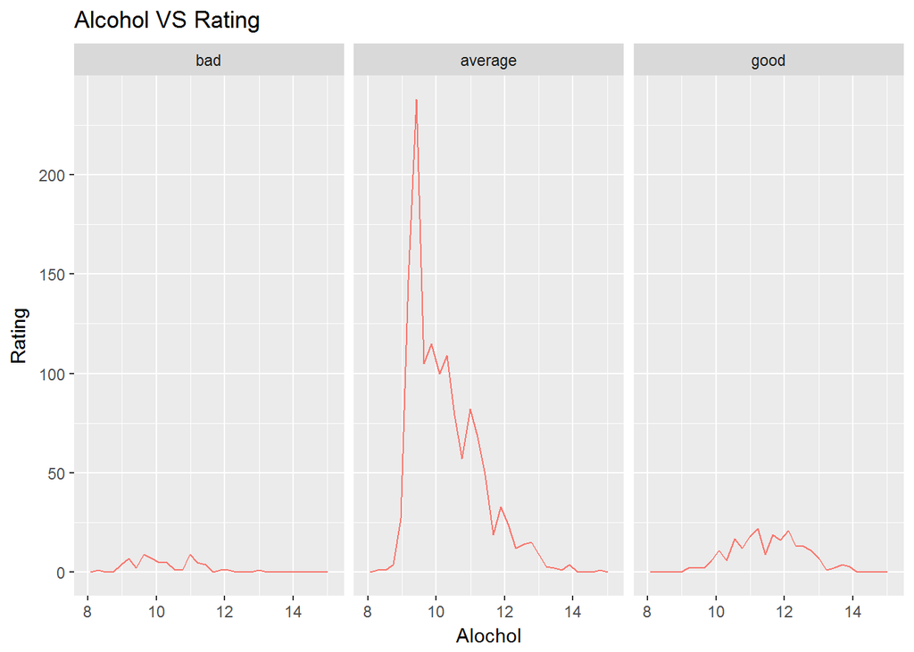

```r
ggplot(red_wine, aes(x =alcohol))+
  geom_freqpoly(aes(color ='red'))+ facet_wrap(~rating)+
  theme(legend.position = "none") +
  ggtitle("Alcohol VS Rating") +
  xlab("Alochol") +
  ylab("Rating")
```

Now let us see quality and volatile acidity

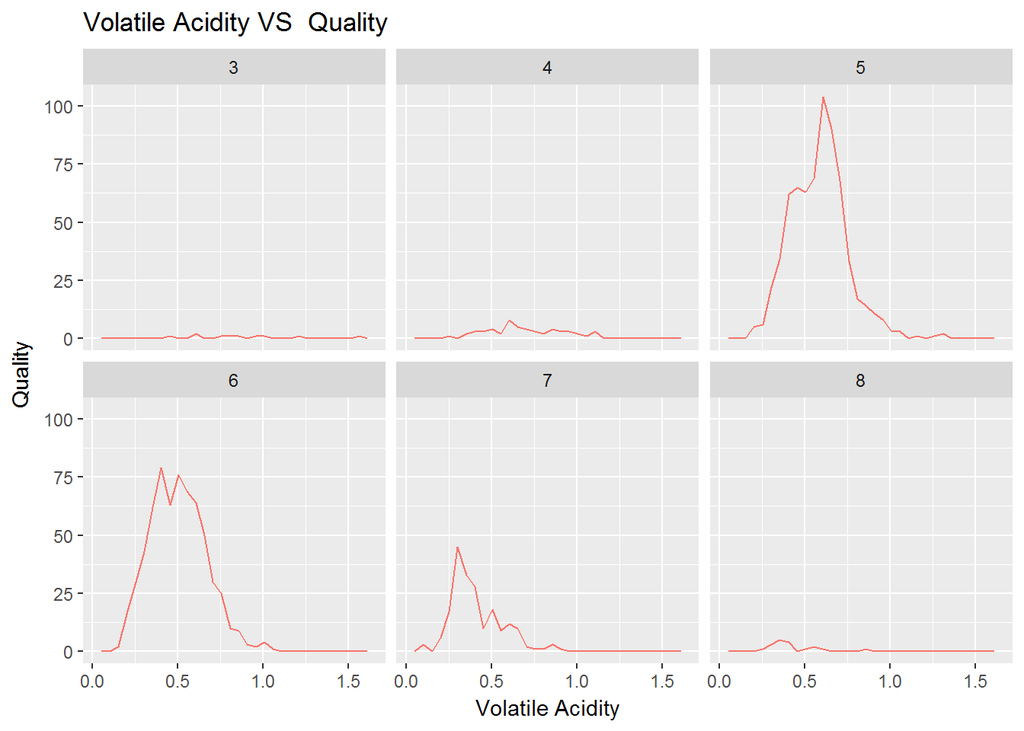

```r
ggplot(red_wine, aes(x =volatile.acidity))+
  geom_freqpoly(aes(color ='red'))+ facet_wrap(~quality)+
  theme(legend.position = "none") +
  ggtitle("Volatile Acidity VS  Quality") +
  xlab("Volatile Acidity") +
  ylab("Quality")
```

We can say the same for Volatile acidity as well that average Rating wine samples have high volume of volatile acid present in them.

# Fixed Acid VS Citric Acid

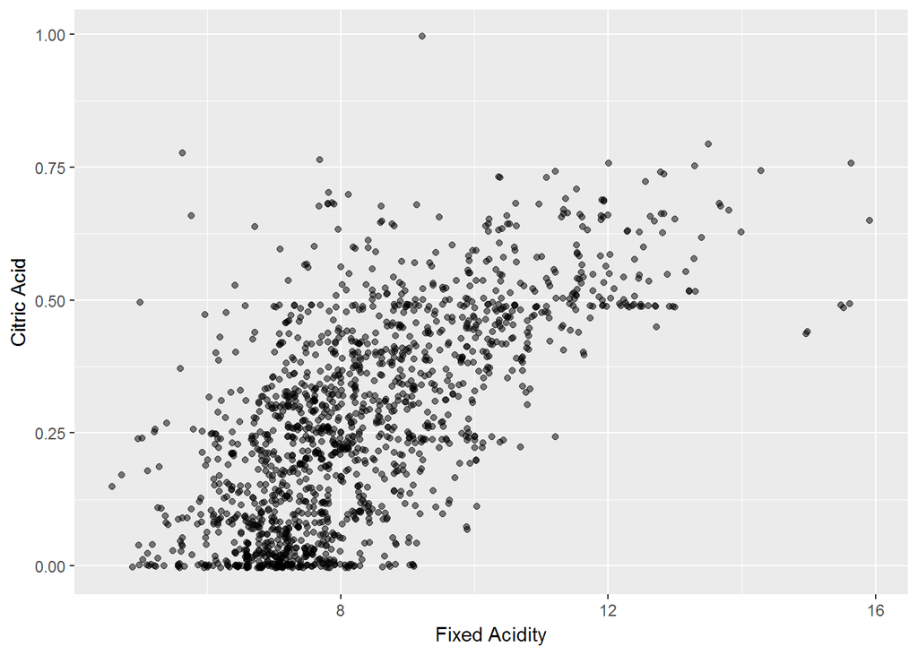

```r
ggplot(red_wine,aes(x = fixed.acidity, y = citric.acid))+
  geom_point(alpha = 0.5, position = "jitter")+
  xlab('Fixed Acidity')+
  ylab('Citric Acid')
```

Since citric acid is one of the components of fixed acidiy hence it is showing such strong correlation.

Lets check the correlation coefficient

```r
cor.test(red_wine$fixed.acidity, red_wine$citric.acid, method ='pearson')
```

```
##
##  Pearson's product-moment correlation
##
## data:  red_wine$fixed.acidity and red_wine$citric.acid
## t = 36.234, df = 1597, p-value < 2.2e-16
## alternative hypothesis: true correlation is not equal to 0
## 95 percent confidence interval:
##  0.6438839 0.6977493
## sample estimates:
##       cor
## 0.6717034
```

I used pearson method to calculate pearson between fixed acid and citric acid and the coeficient cme to be 0.6717.A good rule of thumb says that coefficient above 0.5 is moderate and coefficient above 0.7 is good.So this shows almost good rleationship between the two.

# Fixed Acid VS Density

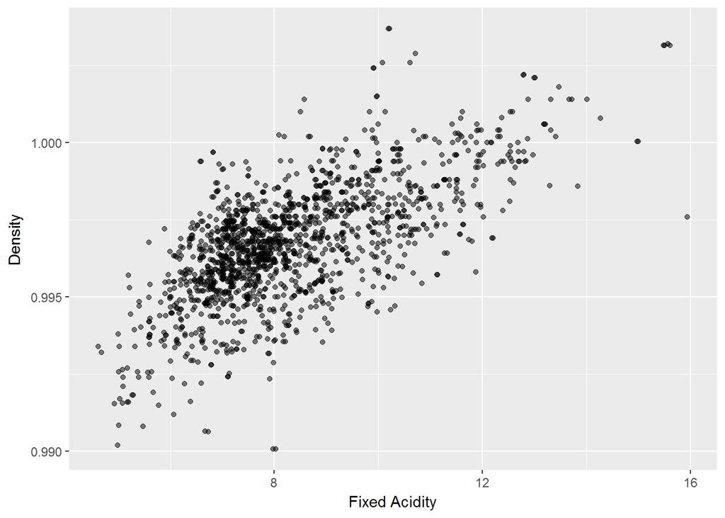

```r
ggplot(red_wine, aes(x = fixed.acidity, y =density))+
  geom_point(alpha = 0.5, position = "jitter")+
  xlab('Fixed Acidity')+
  ylab('Density')
```

Most data is clustered around 0.995 to 1 g/dm3 density and 7 to 8.5 g/dm3. Here i used jitter to add small amount of random variation to the location of each point, and is a useful way of handling overplotting caused by discreteness in smaller datasets. Also alpha parameter is used to set transparency of each point.